# Single-cell RNAseq analysis

Gisela Gabernet

August 04, 2021

QBiC

**Project Members:**

**QBiC contacts:**

Bioinformatics project manager

# 1 Introduction

# 2 Loading the dataset

# 3 Standard pre-processing workflow

Important QC params for eliminating bad quality cells (could be droplets without cells) are:

- Number of unique genes detected in each cell
- Total number of molecules detected within a cell

Calculating the percentage of genes mapping to mitochondrial genome for QC:

- Low-quality / dying cells often exhibit extensive mitochondrial contamination
- We calculate mitochondrial QC metrics with the PercentageFeatureSet function, which calculates the percentage of counts originating from a set of features
- We use the set of all genes starting with mt- as a set of mitochondrial genes

Visualization of the QC metrics:

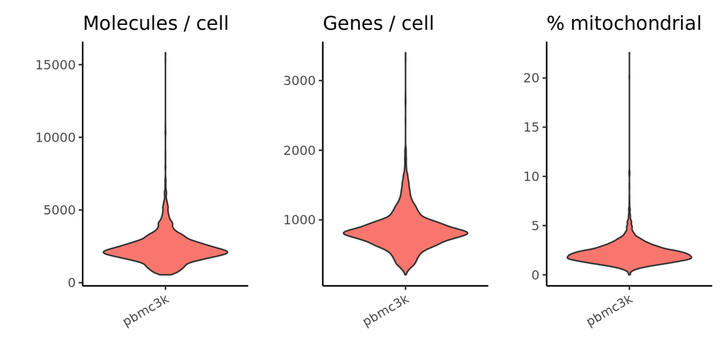

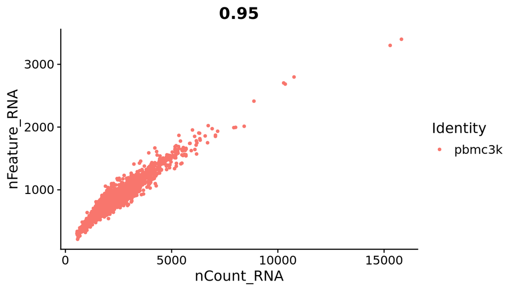

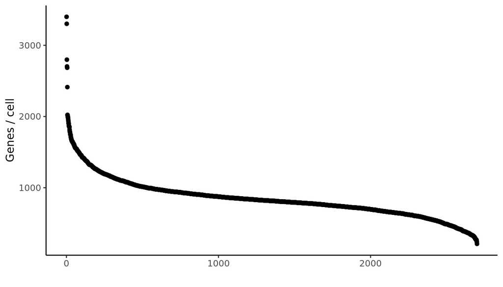

## 3.1 Filtering out low quality cells

Low quality cells need to be filtered out:

- Filtering out the cells that have unique feature counts over 2500 or less than 200
- Filtering out cells that have >5% mitochondrial counts

After filtering low quality cells, the cell numbers per sample are the following:

| Condition | Cell_number |
| --- | --- |
| pbmc3k | 2638 |

# 4 Data normalization and clustering

## 4.1 Data normalization

Sample variable features:

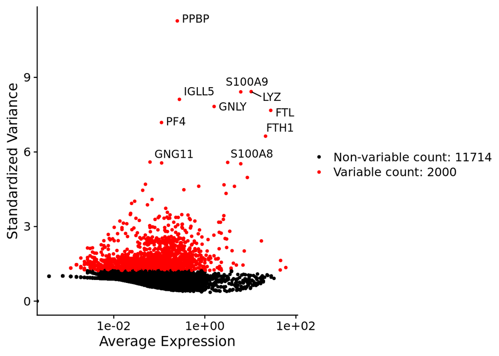

## 4.2 PCA analysis

Perform linear dimensionality reduction on the variable features.

```
## PC_ 1
## Positive:  CST3, TYROBP, LST1, AIF1, FTL
## Negative:  MALAT1, LTB, IL32, IL7R, CD2
## PC_ 2
## Positive:  CD79A, MS4A1, TCL1A, HLA-DQA1, HLA-DQB1
## Negative:  NKG7, PRF1, CST7, GZMB, GZMA
## PC_ 3
## Positive:  HLA-DQA1, CD79A, CD79B, HLA-DQB1, HLA-DPB1
## Negative:  PPBP, PF4, SDPR, SPARC, GNG11
## PC_ 4
## Positive:  HLA-DQA1, CD79B, CD79A, MS4A1, HLA-DQB1
## Negative:  VIM, IL7R, S100A6, IL32, S100A8
## PC_ 5
## Positive:  GZMB, NKG7, S100A8, FGFBP2, GNLY
## Negative:  LTB, IL7R, CKB, VIM, MS4A7
```

Visualizing the loadings

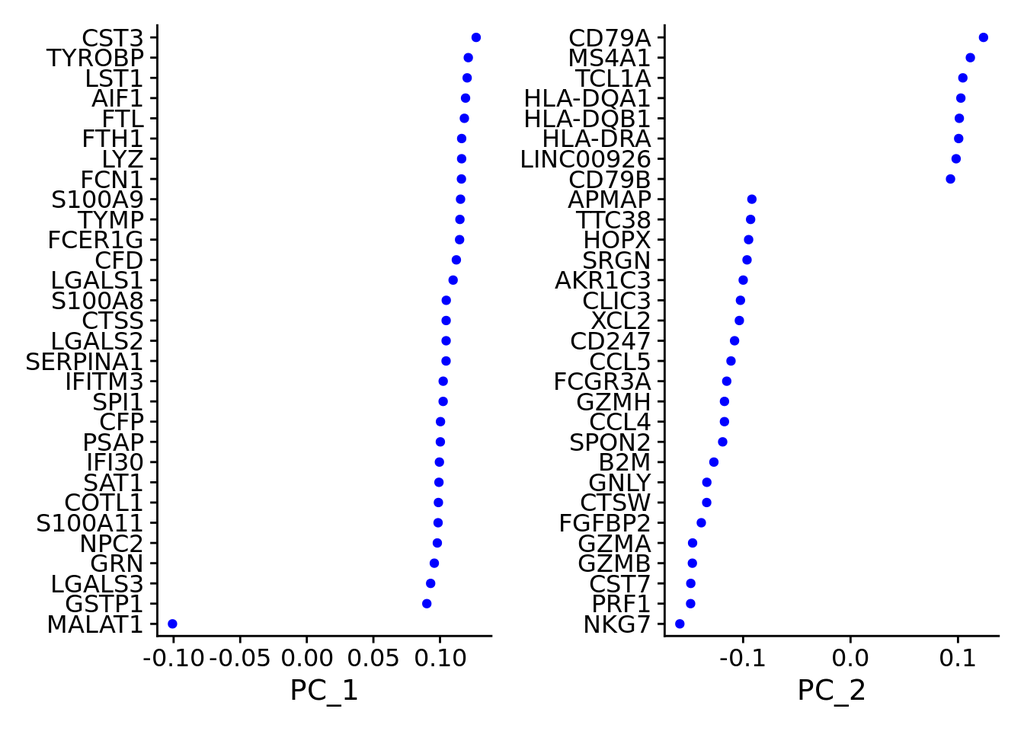

Visualizing the elbow plot

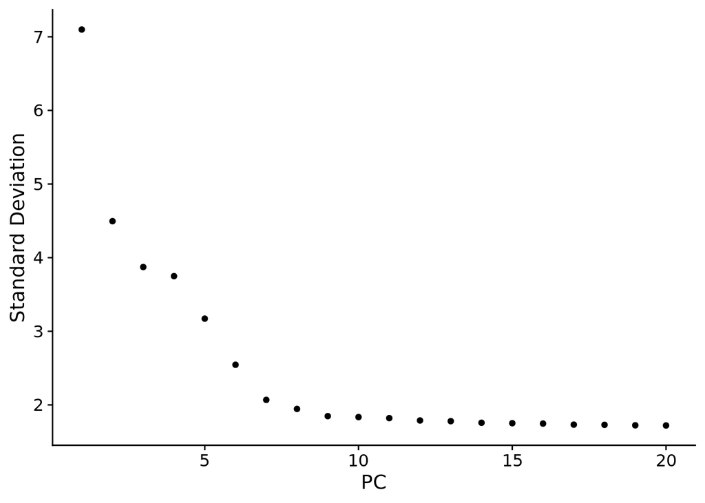

## 4.3 Clustering the cells

## 4.4 Run non-linear dimensionality reduction

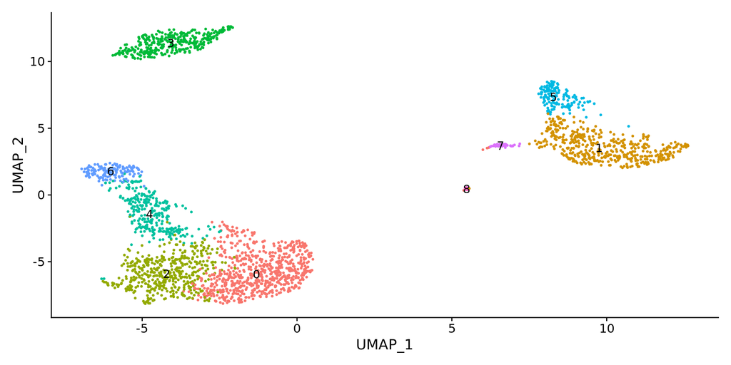

# 5 Plotting cell type markers

All marker plots in this section can be found under results/markers.

## 5.1 Markers described in the literature

DotPlot from genes in the Nature communications CSF paper.

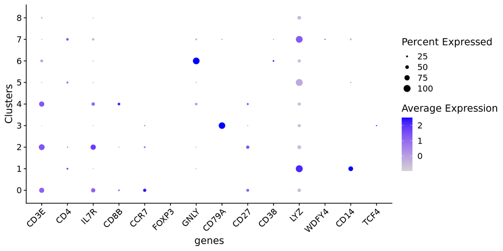

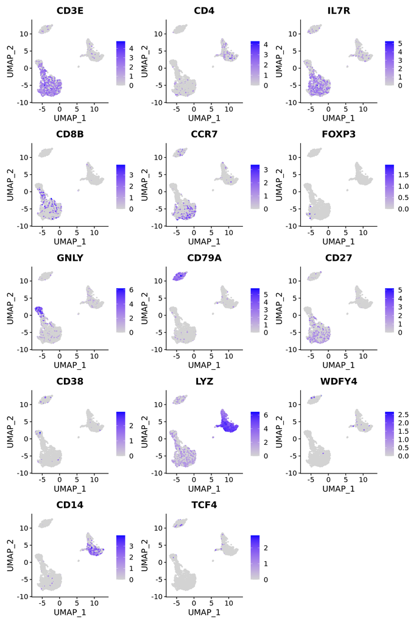

# 6 Methods

For the single-cell data analysis the R package Seurat v4.0.3 was employed. Graphs were produced in RStudio with R version 4.0.3 (2020-10-10) mainly using the `R` package ggplot2 v3.3.3. Final reports were produced using the `R` package rmarkdown v2.9, with knitr v1.33.

Package versions:

```r
installed.packages()[names(sessionInfo()$otherPkgs), "Version"]
```

```
## pbmc3k.SeuratData        SeuratData        kableExtra             knitr
##           "3.1.4"           "0.2.1"           "1.3.4"            "1.33"
##           cowplot             limma           ggplot2           forcats
##           "1.1.1"          "3.46.0"           "3.3.3"           "0.5.1"
##         patchwork      SeuratObject            Seurat             dplyr
##           "1.1.1"           "4.0.2"           "4.0.3"           "1.0.6"
```